# Regression_Levesque_Guillaume

```python
import pandas as pd
import numpy as np
import matplotlib.pyplot as plt
import seaborn as sns
```

```python
# suppression des messages warnings
import warnings
warnings.filterwarnings("ignore")
```

```python
df = pd.read_csv('credit_immobilier_ISF.csv')
```

## Analyse des données

Exploration du jeu de données

```python
df.shape
```

```
(1021, 17)
```

```python
df.info()
```

```
<class 'pandas.core.frame.DataFrame'>
RangeIndex: 1021 entries, 0 to 1020
Data columns (total 17 columns):
 #   Column                    Non-Null Count  Dtype
---  ------                    --------------  -----
 0   compte_courant            1021 non-null   object
 1   duree_emprunt_mois        1021 non-null   int64
 2   historique_credit         1021 non-null   object
 3   raison                    1021 non-null   object
 4   montant                   1021 non-null   int64
 5   compte_epargne            1020 non-null   object
 6   duree_emploi              1021 non-null   object
 7   annees_presence_logement  1018 non-null   float64
 8   age                       1020 non-null   float64
 9   autre_credit              1021 non-null   object
 10  logement                  1021 non-null   object
 11  nbre_emprunts_actuels     1021 non-null   int64
 12  job                       1018 non-null   object
 13  dependants                1021 non-null   object
 14  telephone                 1021 non-null   object
 15  defaillant                1020 non-null   object
 16  revenufinal               1021 non-null   float64
dtypes: float64(3), int64(3), object(11)
memory usage: 135.7+ KB
```

```python
df.head()
```

|  | compte_courant | duree_emprunt_mois | historique_credit | raison | montant | compte_epargne | duree_emploi | annees_presence_logement | age | autre_credit | logement | nbre_emprunts_actuels | job | dependants | telephone | defaillant | revenufinal |
| --- | --- | --- | --- | --- | --- | --- | --- | --- | --- | --- | --- | --- | --- | --- | --- | --- | --- |
| 0 | < 0 Euro | 6 | critique | ameublement | 1169 | inconnu | > 7 annees | 4.0 | 67.0 | aucun | proprietaire | 2 | qualifie | 1 | oui | non | 8135.110140 |
| 1 | 1 - 200 Euro | 48 | bon | ameublement | 5951 | < 100 Euro | 1 - 4 annees | 2.0 | 22.0 | aucun | proprietaire | 1 | qualifie | 1 | oui | oui | 19334.307686 |
| 2 | inconnu | 12 | critique | education | 2096 | < 100 Euro | 4 - 7 annees | 3.0 | 49.0 | aucun | proprietaire | 1 | non_qualifie | 2 | oui | non | 4864.954258 |
| 3 | < 0 Euro | 42 | bon | ameublement | 7882 | < 100 Euro | 4 - 7 annees | 4.0 | 45.0 | aucun | autre | 1 | qualifie | 2 | oui | non | 22152.947349 |
| 4 | < 0 Euro | 24 | pauvre | auto | 4870 | < 100 Euro | 1 - 4 annees | 4.0 | 53.0 | aucun | autre | 2 | qualifie | 2 | oui | oui | 23900.704144 |

Variables numériques :

```python
df.describe().transpose()
```

|  | count | mean | std | min | 25% | 50% | 75% | max |
| --- | --- | --- | --- | --- | --- | --- | --- | --- |
| duree_emprunt_mois | 1021.0 | 20.770813 | 12.050318 | 4.000000 | 12.000000 | 18.000000 | 24.000000 | 72.000000 |
| montant | 1021.0 | 3250.088149 | 2830.788792 | 250.000000 | 1352.000000 | 2299.000000 | 3966.000000 | 18424.000000 |
| annees_presence_logement | 1018.0 | 2.844794 | 1.104864 | 1.000000 | 2.000000 | 3.000000 | 4.000000 | 4.000000 |
| age | 1020.0 | 35.491176 | 11.395078 | 19.000000 | 27.000000 | 33.000000 | 42.000000 | 75.000000 |
| nbre_emprunts_actuels | 1021.0 | 1.409403 | 0.576390 | 1.000000 | 1.000000 | 1.000000 | 2.000000 | 4.000000 |
| revenufinal | 1021.0 | 12273.073874 | 11200.509536 | 734.476054 | 5192.478646 | 8615.582896 | 15559.590686 | 79354.527366 |

Variables catégorielles

```python
df.describe(include='object')
```

|  | compte_courant | historique_credit | raison | compte_epargne | duree_emploi | autre_credit | logement | job | dependants | telephone | defaillant |
| --- | --- | --- | --- | --- | --- | --- | --- | --- | --- | --- | --- |
| count | 1021 | 1021 | 1021 | 1020 | 1021 | 1021 | 1021 | 1018 | 1021 | 1021 | 1020 |
| unique | 4 | 5 | 6 | 5 | 6 | 4 | 4 | 5 | 3 | 1 | 2 |
| top | inconnu | bon | ameublement | < 100 Euro | 1 - 4 annees | aucun | proprietaire | qualifie | 1 | oui | non |
| freq | 402 | 535 | 486 | 611 | 349 | 834 | 731 | 648 | 864 | 1021 | 717 |

```python
echantillonColonnes = []
for i in df.columns:
    listcolumn = str(list(df[i].head(5)))
    echantillonColonnes.append(listcolumn)
```

```python
#data frame colonnes rassemblant les données précédentes pour vérification si anomalies flagrantes
d = {'colonne': list(df.columns), 'type': list(df.dtypes), 'Echantillon':echantillonColonnes}
colonnesTypes = pd.DataFrame(data=d)

pd.options.display.max_rows = 24
colonnesTypes
```

|  | colonne | type | Echantillon |
| --- | --- | --- | --- |
| 0 | compte_courant | object | ['< 0 Euro', '1 - 200 Euro', 'inconnu', '< 0 E... |
| 1 | duree_emprunt_mois | int64 | [6, 48, 12, 42, 24] |
| 2 | historique_credit | object | ['critique', 'bon', 'critique', 'bon', 'pauvre'] |
| 3 | raison | object | ['ameublement', 'ameublement', 'education', 'a... |
| 4 | montant | int64 | [1169, 5951, 2096, 7882, 4870] |
| 5 | compte_epargne | object | ['inconnu', '< 100 Euro', '< 100 Euro', '< 100... |
| 6 | duree_emploi | object | ['> 7 annees', '1 - 4 annees', '4 - 7 annees',... |
| 7 | annees_presence_logement | float64 | [4.0, 2.0, 3.0, 4.0, 4.0] |
| 8 | age | float64 | [67.0, 22.0, 49.0, 45.0, 53.0] |
| 9 | autre_credit | object | ['aucun', 'aucun', 'aucun', 'aucun', 'aucun'] |
| 10 | logement | object | ['proprietaire', 'proprietaire', 'proprietaire... |
| 11 | nbre_emprunts_actuels | int64 | [2, 1, 1, 1, 2] |
| 12 | job | object | ['qualifie', 'qualifie', 'non_qualifie', 'qual... |
| 13 | dependants | object | ['1', '1', '2', '2', '2'] |
| 14 | telephone | object | ['oui', 'oui', 'oui', 'oui', 'oui'] |
| 15 | defaillant | object | ['non', 'oui', 'non', 'non', 'oui'] |
| 16 | revenufinal | float64 | [8135.1101404539, 19334.307686113898, 4864.954... |

```python
categorical = ["compte_courant", "historique_credit","raison","compte_epargne","duree_emploi","autre_credit","logement","job","dependants","telephone","defaillant"]
numerical = ["duree_emprunt_mois", "annees_presence_logement", "age", "nbre_emprunts_actuels", "revenufinal"]
```

### Séparation variables explicatives/à expliquer

```python
y = df["montant"]
X = df.loc[:, df.columns != 'montant']
```

### Traitement des données manquantes

Identification des valeurs manquantes par colonne :

```python
X.isnull().sum()
```

```
compte_courant              0
duree_emprunt_mois          0
historique_credit           0
raison                      0
compte_epargne              1
duree_emploi                0
annees_presence_logement    3
age                         1
autre_credit                0
logement                    0
nbre_emprunts_actuels       0
job                         3
dependants                  0
telephone                   0
defaillant                  1
revenufinal                 0
dtype: int64
```

```python
y.isnull().sum()
```

```
0
```

Etude des variables explicatives contenant des valeurs manquantes :

```python
print(X["job"].unique())
print(X["annees_presence_logement"].unique())
print(X["defaillant"].unique())
print(X["compte_epargne"].unique())
print(X["age"].unique())
```

```
['qualifie' 'non_qualifie' 'management' 'oui' 'chomeur' nan]
[ 4.  2.  3.  1. nan]
['non' 'oui' nan]
['inconnu' '< 100 Euro' '500 - 1000 Euro' '> 1000 Euro' '100 - 500 Euro'
 nan]
[67. 22. 49. 45. 53. 35. 61. 28. 25. 24. 60. 32. 44. 31. 48. 26. 36. 39.
 42. 34. nan 27. 30. 57. 33. 37. 58. 23. 29. 52. 50. 46. 51. 41. 40. 66.
 47. 56. 54. 20. 63. 21. 38. 70. 65. 74. 68. 43. 55. 64. 75. 19. 62. 59.]
```

Pour commencer nous remarquons que des valeurs manquantes/valeurs mal définies se cachent derrière certaines modalités (comme par exemple la modalité "oui" de la variable job) :

```python
X["job"] = X["job"].replace('oui',np.NaN)
X["compte_epargne"] = X["compte_epargne"].replace(np.NaN,"inconnu")
```

Rergardons si il en est de même pour les autres variables explicatives qualitatives :

```python
print(X["compte_courant"].unique())
print(X["historique_credit"].unique())
print(X["raison"].unique())
print(X["duree_emploi"].unique())
print(X["autre_credit"].unique())
print(X["logement"].unique())
print(X["dependants"].unique())
print(X["telephone"].unique())
```

```
['< 0 Euro' '1 - 200 Euro' 'inconnu' '> 200 Euro']
['critique' 'bon' 'pauvre' 'parfait' 'tres bon']
['ameublement' 'education' 'auto' 'business' 'renonvations' 'auto0']
['> 7 annees' '1 - 4 annees' '4 - 7 annees' 'chomeur' '< 1 annee'
 '> 7 annes']
['aucun' 'banque' '2' 'magasin']
['proprietaire' 'autre' 'locataire' 'qualifie']
['1' '2' 'oui']
['oui']
```

C'est effectivement le cas, nous allons donc appliquer un retraitement en conséquence :

```python
X["raison"] = X["raison"].replace("auto0","auto")
X["duree_emploi"] = X["duree_emploi"].replace('> 7 annes','> 7 annees')
X["autre_credit"] = X["autre_credit"].replace("2",np.NaN)
X["logement"] = X["logement"].replace('qualifie',np.NaN)
X["dependants"] = X["dependants"].replace("oui",np.NaN)
```

```python
X = X.drop(["telephone"], axis=1)
categorical = ["compte_courant", "historique_credit","raison","compte_epargne","duree_emploi","autre_credit","logement","job","dependants","defaillant"]
```

Etude des lignes contenant des valeurs manquantes :

```python
mask = False
for col in X.columns : mask = mask | X[col].isnull()
dfnulls = X[mask]

dfnulls
```

|  | compte_courant | duree_emprunt_mois | historique_credit | raison | compte_epargne | duree_emploi | annees_presence_logement | age | autre_credit | logement | nbre_emprunts_actuels | job | dependants | defaillant | revenufinal |
| --- | --- | --- | --- | --- | --- | --- | --- | --- | --- | --- | --- | --- | --- | --- | --- |
| 29 | inconnu | 7 | critique | ameublement | < 100 Euro | > 7 annees | NaN | NaN | NaN | NaN | 1 | NaN | NaN | NaN | 6584.168778 |
| 413 | inconnu | 15 | bon | auto | 500 - 1000 Euro | > 7 annees | NaN | 31.0 | aucun | proprietaire | 2 | qualifie | 2 | non | 6493.120171 |
| 709 | 1 - 200 Euro | 18 | pauvre | auto | < 100 Euro | > 7 annees | NaN | 42.0 | aucun | autre | 1 | qualifie | 1 | oui | 31068.029379 |
| 826 | 1 - 200 Euro | 8 | bon | business | < 100 Euro | < 1 annee | 2.0 | 26.0 | aucun | proprietaire | 1 | NaN | 1 | non | 3070.511597 |
| 853 | inconnu | 4 | bon | ameublement | < 100 Euro | < 1 annee | 3.0 | 23.0 | aucun | locataire | 1 | NaN | 2 | non | 1056.317863 |
| 858 | inconnu | 18 | bon | renonvations | < 100 Euro | < 1 annee | 4.0 | 23.0 | aucun | proprietaire | 1 | NaN | 1 | oui | 9862.654808 |

```python
# dans df_na uniquement les variables pour lesquelles il y a des valeurs manquantes
df_na = (X.isnull().sum() / len(X))
df_na = df_na.drop(df_na[df_na == 0].index).sort_values(ascending=False)
missing_df = pd.DataFrame({'Ratio valeurs manquantes' : df_na})
missing_df
```

|  | Ratio valeurs manquantes |
| --- | --- |
| job | 0.003918 |
| annees_presence_logement | 0.002938 |
| defaillant | 0.000979 |
| dependants | 0.000979 |
| logement | 0.000979 |
| autre_credit | 0.000979 |
| age | 0.000979 |

```python
X.isnull().sum()
```

```
compte_courant              0
duree_emprunt_mois          0
historique_credit           0
raison                      0
compte_epargne              0
duree_emploi                0
annees_presence_logement    3
age                         1
autre_credit                1
logement                    1
nbre_emprunts_actuels       0
job                         4
dependants                  1
defaillant                  1
revenufinal                 0
dtype: int64
```

Il y a donc très peu de valeurs manquantes. Nous allons appliquer un retraitement de ces dernières adapté à ce que nous venons d'observer.

### Traitement des données manquantes au sein des variables explicatives :

Concernant la donnée manquante de la variable age, au vu du nombre de variables explicatives et d'observations à disposition, nous avons suffisament d'information pour estimer sa valeur en fonction des individus lui "ressemblant le plus". Pour cela nous utiliserons une méthode des k-Plus proches voisins.

Pour information, nous préférons ici cette option à celle qui consiste à remplacer cette valeur par la moyenne (ou mediane) de la colonne age puisqu'elle semble plus adaptée et pertinente dans ce cas de figure précis.

Nous allons également appliquer cette méthode aux valeurs manquantes des variables "logement", "job", "dependants" et "defaillant".

```python
from sklearn.impute import KNNImputer

# Nous considérerons les 10 PPV afin d'avoir un "échantillon représentatif de profils similaires"

imputer = KNNImputer(n_neighbors=10)

#Nous allons temporairement associer des entiers distincts aux modalités des variables qualitatives afin de permettre
#l'entrainement du modèle des k-PPV (k=10 ici)

df_temp = X.copy()   #On utilise .copy() pour éviter que les changments appliqués à df_temp ne se répercutent sur X.
df_temp[categorical] = df_temp[categorical].astype('category')
df_temp[categorical] = df_temp[categorical].apply(lambda x: x.cat.codes)
```

Afin que l'algorithme des k-PPV puisse correctement identifier les valeurs manquantes il nous faut appliquer une dernière transformation :

```python
df_temp["job"] = df_temp["job"].replace(-1,np.NaN)
df_temp["logement"] = df_temp["logement"].replace(-1,np.NaN)
df_temp["dependants"] = df_temp["dependants"].replace(-1,np.NaN)
df_temp["defaillant"] = df_temp["defaillant"].replace(-1,np.NaN)
df_temp["autre_credit"] = df_temp["autre_credit"].replace(-1,np.NaN)
```

```python
imputed = imputer.fit_transform(df_temp)
df_imputed = pd.DataFrame(imputed, columns=df_temp.columns)

####

print("Nous allons donc remplacer l'âge du 29ème individu initialement ",X.loc[29,"age"] ," par ", round(df_imputed.loc[29,"age"]))

####

print("Nous allons donc remplacer le métier du 29ème individu initialement ",X.loc[29,"job"] ," par ", df_imputed.loc[29,"job"], "c'est à dire par la modalité qualifie")
print("Nous allons remplacer le métier du 826ème individu initialement ",X.loc[826,"job"] ," par ", df_imputed.loc[826,"job"], "c'est à dire par la modalité non_qualifie")
print("Nous allons remplacer le métier du 853ème individu initialement ",X.loc[853,"job"] ," par ", df_imputed.loc[853,"job"], "c'est à dire par la modalité non_qualifie")
print("Nous allons remplacer le métier du 858ème individu initialement ",X.loc[858,"job"] ," par ", df_imputed.loc[858,"job"], "c'est à dire par la modalité non_qualifie")

####

print("Nous allons donc remplacer la situation immobilière du 29ème individu initialement ",X.loc[29,"logement"] ," par ", df_imputed.loc[29,"logement"], "c'est à dire par la modalité proprietaire")

####

print("Nous allons donc remplacer la dependance du 29ème individu initialement ",X.loc[29,"dependants"] ," par ", df_imputed.loc[29,"dependants"], "c'est à dire par la modalité 1")

####

print("Nous allons donc remplacer la defaillance du 29ème individu initialement ",X.loc[29,"defaillant"] ," par ", df_imputed.loc[29,"defaillant"], "c'est à dire par la modalité non")

####

print("Nous allons donc remplacer la situation crédit du 29ème individu initialement ",X.loc[29,"autre_credit"] ," par ", df_imputed.loc[29,"autre_credit"], "c'est à dire par la modalité aucun")
```

```
Nous allons donc remplacer l'âge du 29ème individu initialement  nan  par  35
Nous allons donc remplacer le métier du 29ème individu initialement  nan  par  2.8 c'est à dire par la modalité qualifie
Nous allons remplacer le métier du 826ème individu initialement  nan  par  2.4 c'est à dire par la modalité non_qualifie
Nous allons remplacer le métier du 853ème individu initialement  nan  par  2.0 c'est à dire par la modalité non_qualifie
Nous allons remplacer le métier du 858ème individu initialement  nan  par  2.3 c'est à dire par la modalité non_qualifie
Nous allons donc remplacer la situation immobilière du 29ème individu initialement  nan  par  1.7 c'est à dire par la modalité proprietaire
Nous allons donc remplacer la dependance du 29ème individu initialement  nan  par  0.1 c'est à dire par la modalité 1
Nous allons donc remplacer la defaillance du 29ème individu initialement  nan  par  0.2 c'est à dire par la modalité non
Nous allons donc remplacer la situation crédit du 29ème individu initialement  nan  par  0.2 c'est à dire par la modalité aucun
```

```python
X.loc[29,"age"] = round(df_imputed.loc[29,"age"])

X.loc[29,"job"] = "qualifie"
X.loc[826,"job"] = "non_qualifie"
X.loc[853,"job"] = "non_qualifie"
X.loc[858,"job"] = "non_qualifie"

X.loc[29,"logement"] = "proprietaire"

X.loc[29,"dependants"] = "1"

X.loc[29,"defaillant"] = "non"

X.loc[29,"autre_credit"] = "aucun"
```

Ceci dit en passant, si on prend l'age du 29ème individu après traitement des valeurs manquantes, la nouvelle valeur 35 semble très cohérente avec le fait que cet individu travaille depuis plus de 7 ans !

Pour finir, la durée de présence dans un même logement semblant relativement indépendante des informations apportées par les autres variables explicatives à disposition. De ce fait, nous remplacerons les NaN par la moyenne de la colonne "annees_presence_logement" :

```python
X['annees_presence_logement'] = X['annees_presence_logement'].fillna(round(X['annees_presence_logement'].mean()))
```

```python
X.isnull().sum()
```

```
compte_courant              0
duree_emprunt_mois          0
historique_credit           0
raison                      0
compte_epargne              0
duree_emploi                0
annees_presence_logement    0
age                         0
autre_credit                0
logement                    0
nbre_emprunts_actuels       0
job                         0
dependants                  0
defaillant                  0
revenufinal                 0
dtype: int64
```

Ceci achève notre partie "traitement des valeurs manquantes".

### Traitement des outliers et visualisation de nos données

Commençons par observer la target, à titre informatif :

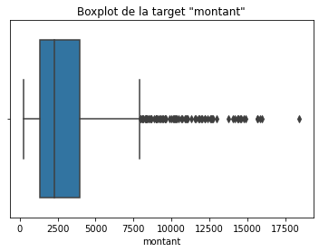

```python
import scipy.stats as stats
sns.boxplot(y)
plt.title('Boxplot de la target "montant"')
```

```python
y.describe()
```

```
count     1021.000000
mean      3250.088149
std       2830.788792
min        250.000000
25%       1352.000000
50%       2299.000000
75%       3966.000000
max      18424.000000
Name: montant, dtype: float64
```

Tout d'abord passons les variables explicatives numériques discretes à peu de modalités dans la "catégorie qualitatives" :

```python
qualitatives = ["annees_presence_logement", "nbre_emprunts_actuels", "compte_courant", "historique_credit","raison","compte_epargne","duree_emploi","autre_credit","logement","job","dependants","defaillant"]
quantitatives = ["duree_emprunt_mois",  "age",  "revenufinal"]
```

Observation de la répartition des variables explicatives qualitatives :

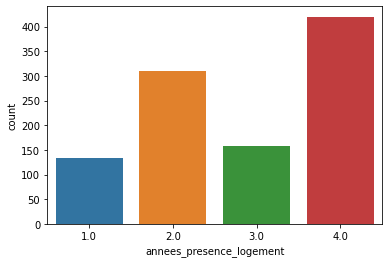

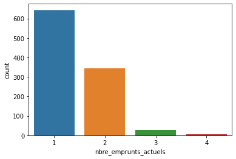

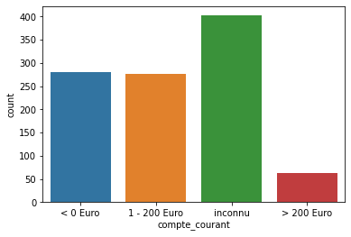

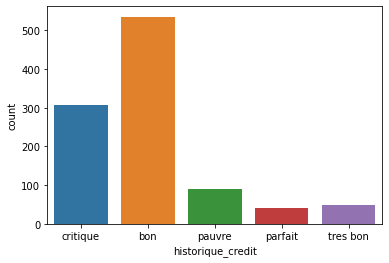

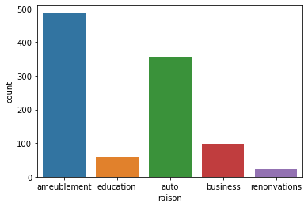

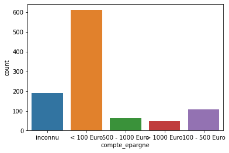

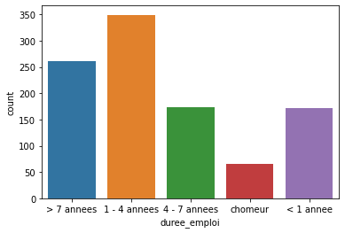

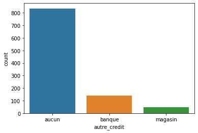

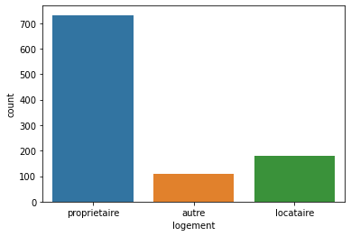

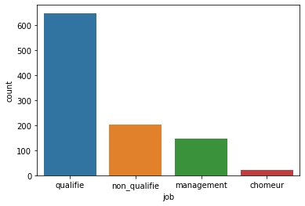

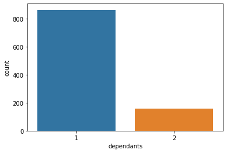

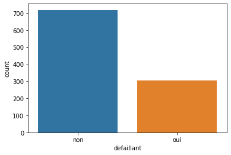

```python
for i in qualitatives:
    sns.countplot(X[i])
    plt.show()
```

Au vu de ces histogrammes nous allons regrouper certaines modalités car trop peu fréquentes (seuil choisi < 3 % ):

```python
X["nbre_emprunts_actuels"] = X["nbre_emprunts_actuels"].replace(4,3)
```

Pour les modalités "chomeur" et "renonvations" des variables "job" et "raison" respectivement, nous devons observer la répartition de la target avant un éventuel regroupement de modalités :

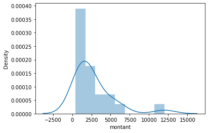

```python
sns.distplot(y[X["raison"]=="renonvations"])
```

```python
y[X["raison"]=="renonvations"].describe()
```

```
count       22.000000
mean      2728.090909
std       2627.490364
min        454.000000
25%       1214.500000
50%       1749.000000
75%       3203.250000
max      11998.000000
Name: montant, dtype: float64
```

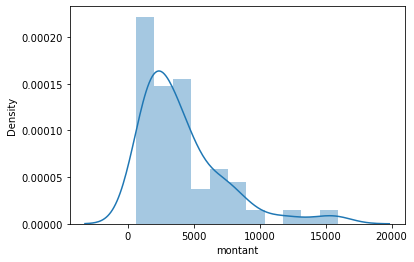

```python
sns.distplot(y[X["raison"]=="business"])
```

```python
y[X["raison"]=="business"].describe()
```

```
count       97.000000
mean      4112.721649
std       3224.354247
min        609.000000
25%       1908.000000
50%       3104.000000
75%       5117.000000
max      15945.000000
Name: montant, dtype: float64
```

Nous pouvons donc conclure, au vu de ces graphiques, qu'au sein de notre population, un credit pour renovation ou pour un business de manière générale aboutissent à des emprunts d'un montant relativement similaire. Nous allons donc pouvoir regrouper ces modalités.

```python
X["raison"] = X["raison"].replace("renonvations","business")
```

Suivant la même démarche pour la variable "job" et sa modalité "chomeur", nous obtenons :

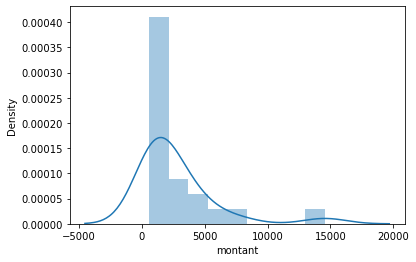

```python
sns.distplot(y[X["job"]=="chomeur"])
```

```python
y[X["job"]=="chomeur"].describe()
```

```
count       22.000000
mean      2745.136364
std       3168.669306
min        609.000000
25%       1117.250000
50%       1416.000000
75%       3541.000000
max      14555.000000
Name: montant, dtype: float64
```

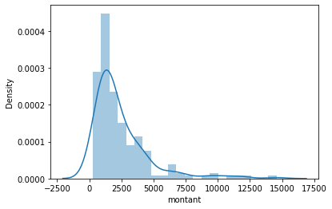

```python
sns.distplot(y[X["job"]=="non_qualifie"])
```

```python
y[X["job"]=="non_qualifie"].describe()
```

```
count      202.000000
mean      2412.841584
std       2227.034975
min        250.000000
25%       1126.750000
50%       1622.000000
75%       3042.000000
max      14576.000000
Name: montant, dtype: float64
```

Nous pouvons donc conclure, de façon encore plus favorable qu'avec la variable "raison" et sa modalité "renonvations", au regroupement de ces modalités.

```python
X["job"] = X["job"].replace("chomeur","non_qualifie")
X["job"] = X["job"].replace("non_qualifie","non_qualifie_chomeur")
# Puis on renomme la modalité pour ne pas gaspiller de l'information.
```

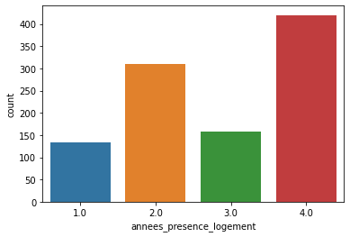

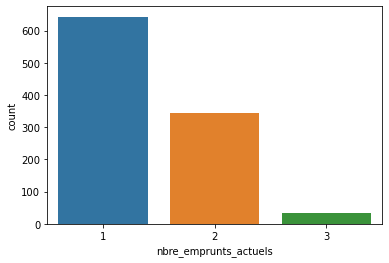

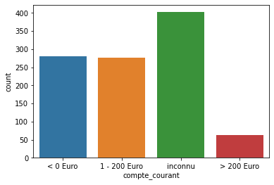

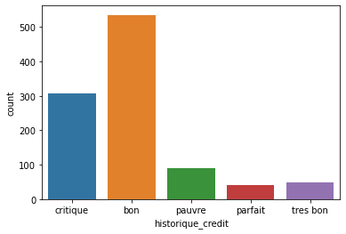

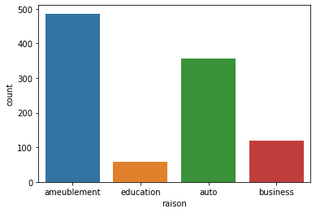

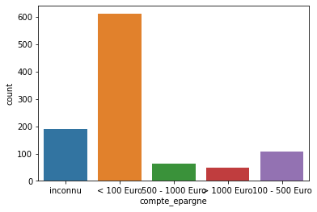

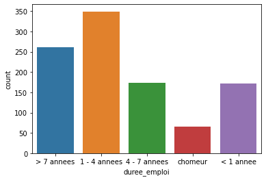

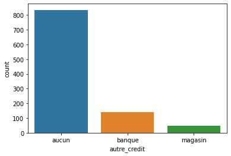

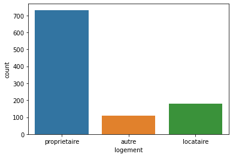

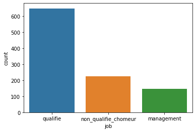

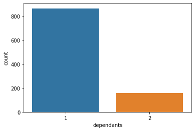

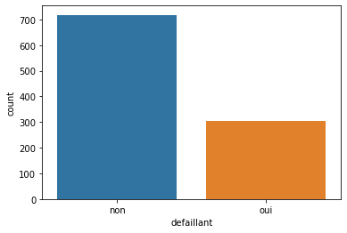

```python
for i in qualitatives:
    sns.countplot(X[i])
    plt.show()
```

Observation de la distribution des variables explicatives quantitatives :

```python
# fonction pour visualisation : histogramme, boxplot et QQplot
def visu_plots(df, variable):
    plt.figure(figsize=(16, 4))
    # histogram
    plt.subplot(1, 3, 1)
    sns.distplot(df[variable], bins=30)
    plt.title('Histogram')
    # boxplot
    plt.subplot(1, 3, 3)
    sns.boxplot(y=df[variable])
    plt.title('Boxplot')
    # Q-Q plot
    plt.subplot(1, 3, 2)
    stats.probplot(df[variable], dist="norm", plot=plt)
    plt.ylabel('Variable quantiles')
    plt.show()
```